# Homework #2

### Chapter 4

#### 1. Slot Machines (Chapter 4 exercises, #3, p. 72)

[5 points]

Do not use *grid.arrange()* for this exercise. Rather, use *gather()* to tidy the data and then facet on window number. To make the comparison, use relative frequency bar charts (the heights of the bars in each facet sum to one). Describe how the distributions differ.

```r
install.packages("gridExtra")
```

```r
d1 <- ggplot(vlt, aes(window1)) +
  geom_bar()
d2 <- ggplot(vlt, aes(window2)) +
  geom_bar()
d3 <- ggplot(vlt, aes(window3)) +
  geom_bar()
grid.arrange(d1, d2, d3)
```

[output not shown]

[output cut: 990 more lines]

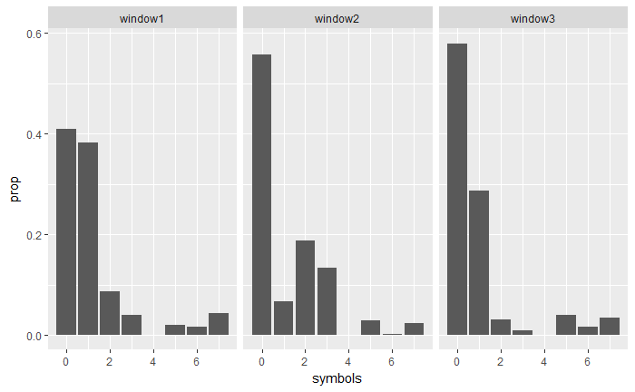

```r
dataf <- data.frame(DAAG::vlt)
d <- gather(dataf, key="windows", value="symbols", window1:window3)
ggplot(d) +
  geom_bar(aes(x=symbols, y=..prop.., group=windows)) +

  facet_wrap(~windows)
```

-The data appears to tbe concentrated towards the left, with the majority on 0 -Symbol 4 appears to not have any data for all three windows

#### 2. Detailed Mortality data (“Death2015.txt”)

[21 points]

```r
# install.packages("gdata")
# library(gdata)
```

This data comes from the “Detailed Mortality” database available on https://wonder.cdc.gov/

```r
deathf = head(read.csv("../Data/Death2015.txt", sep="\t"), -44)
```

```r
head(deathf)
```

|  | Notes | Ten.Year.Age.Groups | Ten.Year.Age.Groups.Code | Place.of.Death | Place.of.Death.Code | ICD.Chapter | ICD.Chapter.Code | ICD.Sub.Chapter | ICD.Sub.Chapter.Code | Deaths | Population | Crude.Rate |
| --- | --- | --- | --- | --- | --- | --- | --- | --- | --- | --- | --- | --- |
| 1 |  | < 1 year | 1 | Medical Facility - Inpatient | 1 | Certain infectious and parasitic diseases | A00-B99 | Intestinal infectious diseases | A00-A09 | 213 | Not Applicable | Not Applicable |
| 2 |  | < 1 year | 1 | Medical Facility - Inpatient | 1 | Certain infectious and parasitic diseases | A00-B99 | Other bacterial diseases | A30-A49 | 184 | Not Applicable | Not Applicable |
| 3 |  | < 1 year | 1 | Medical Facility - Inpatient | 1 | Certain infectious and parasitic diseases | A00-B99 | Infections with a predominantly sexual mode of transmission | A50-A64 | 3 | Not Applicable | Not Applicable |
| 4 |  | < 1 year | 1 | Medical Facility - Inpatient | 1 | Certain infectious and parasitic diseases | A00-B99 | Viral infections of the central nervous system | A80-A89 | 1 | Not Applicable | Not Applicable |
| 5 |  | < 1 year | 1 | Medical Facility - Inpatient | 1 | Certain infectious and parasitic diseases | A00-B99 | Viral infections characterized by skin and mucous membrane lesions | B00-B09 | 8 | Not Applicable | Not Applicable |
| 6 |  | < 1 year | 1 | Medical Facility - Inpatient | 1 | Certain infectious and parasitic diseases | A00-B99 | Human immunodeficiency virus [HIV] disease | B20-B24 | 1 | Not Applicable | Not Applicable |

Code for all preprocessing must be shown. (That is, don’t open in the file in Excel or similar, change things around, save it, and then import to R. Why? Because your steps are not reproducible.)

1. For `Place of Death`, `Ten-Year Age Groups`, and `ICD Chapter Code` variables, do the following:

Identify the type of variable (nominal, ordinal, or discrete) and draw a horizontal bar chart using best practices for order of categories.

1. Place.of.Death is nominal, Ted.Year.Age.Groups is ordinal, and ICD.Chapter is also nomial

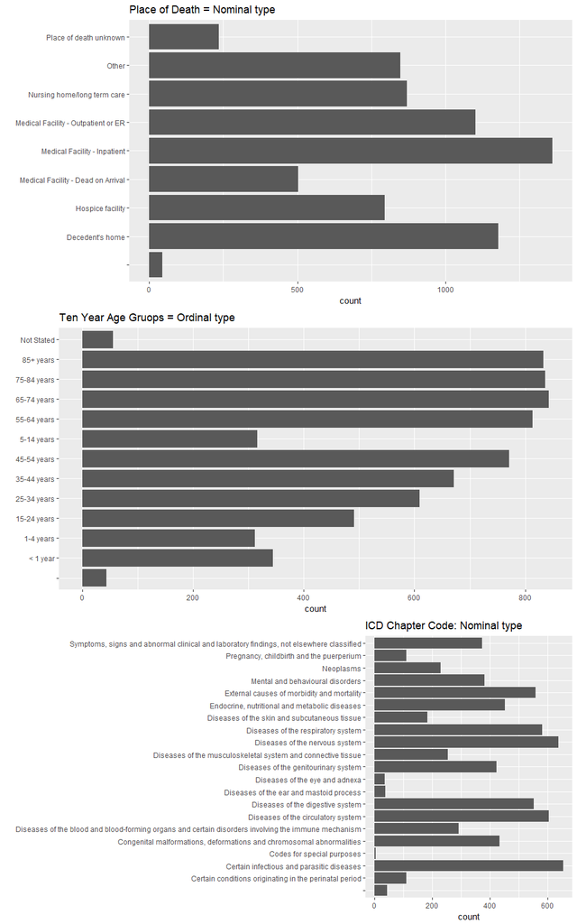

```r
death1.title <- ggtitle("Place of Death = Nominal type")
dtype1 <- ggplot(deathf)+
  geom_bar(aes(Place.of.Death))+
  coord_flip()+
  xlab("")
death2.title <- ggtitle("Ten Year Age Gruops = Ordinal type")
dtype2 <- ggplot(deathf)+
  geom_bar(aes(Ten.Year.Age.Groups))+
  coord_flip()+
  xlab("")
death3.title <- ggtitle("ICD Chapter Code: Nominal type")
dtype3 <- ggplot(deathf)+
  geom_bar(aes(ICD.Chapter))+
  coord_flip()+
  xlab("")
grid.arrange(dtype1+death1.title, dtype2+death2.title, dtype3+death3.title)
```

2. Create horizontal bar charts for the ICD sub-chapter codes, one plot per ICD chapter code, by faceting on chapter code, *not* by using *grid.arrange()*. Use `scales = "free"` with `facet_wrap()`. It should look like this (with data, of course!). Describe notable features.

some of the death types have many more sub types of death, while some only have one or a few. The data appears to be very evenly spread out, where there is no notable trend. What may be causing us to believe this is that some death code types have sufficient data, while others do not.

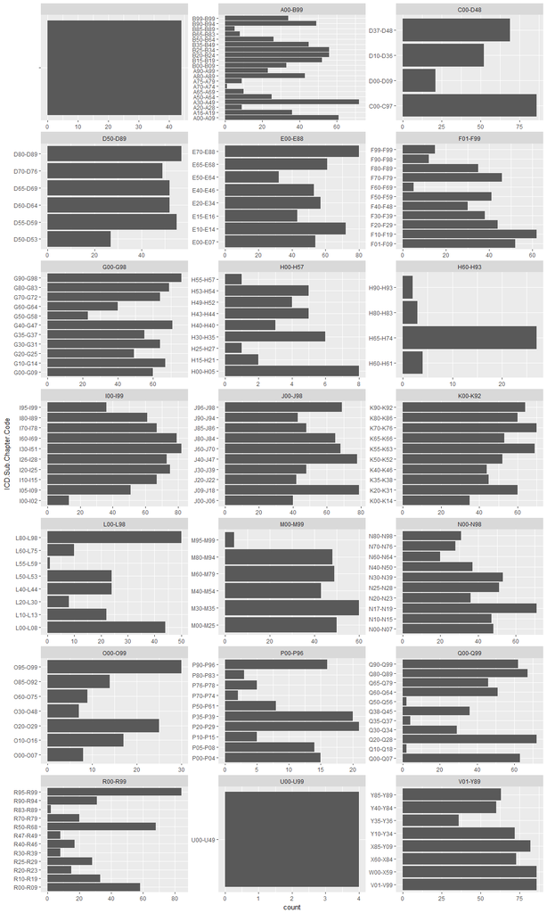

```r
ggplot(deathf) +
  geom_bar(aes(ICD.Sub.Chapter.Code)) +
  facet_wrap(~ICD.Chapter.Code, ncol=3, scales = "free") +
  coord_flip()
```

```r
NA
```

3. Change the `scales` parameter to `scales = "free_y"`. What changed? What information does this set of graphs provide that wasn’t available in part (b)?

we can now see that some of the code types have many more sub codes for cause. we can also see where there is lacking data, such as U00-U99

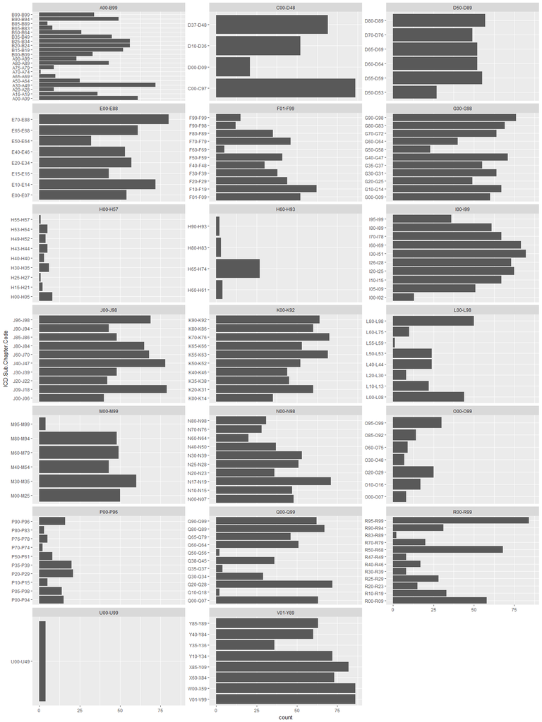

```r
ggplot(deathf) +
  geom_bar(aes(ICD.Sub.Chapter.Code)) +
  facet_wrap(~ICD.Chapter.Code, ncol=3, scales = "free_y") +
  coord_flip()
```

4. Redraw the panels as *relative frequency* bar charts rather than *count* bar charts. (The lengths of the bars *in each panel separately* must sum to 1.) What new information do you gain?

Now that the y values are relative frequencies, we can clearly see how the data is not evenly provided for Chapter Code to Sub Chapter Code.

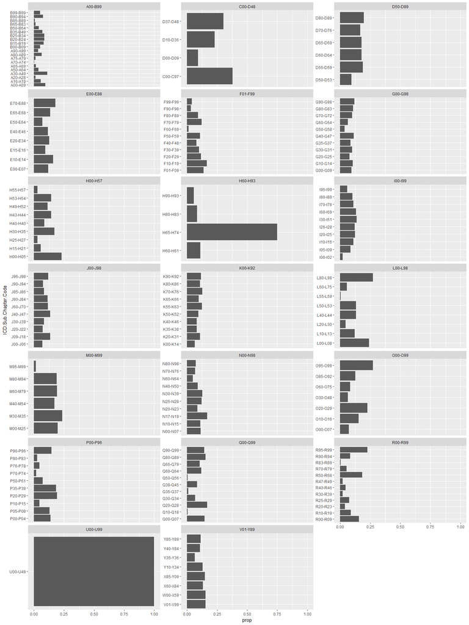

```r
ggplot(deathf) +
  geom_bar(aes(x=ICD.Sub.Chapter.Code, y=..prop.., group=ICD.Chapter.Code)) +
  facet_wrap(~ICD.Chapter.Code, ncol=3, scales = "free_y") +
  coord_flip()
```

5. Choose one of the small panels and redraw it as a single graph, using names rather than codes. (That is, use `ICD Chapter` and `ICD Sub-Chapter` instead of the code versions.) What type of data is this? Note any interesting features.

I broke out the nominal data within the Death Chapter “Diseases of the respiratory system.” The spread of cause of sub chapter breakout is quite uniform. What is surprising though is the number of “other” diseases called out. It would be interesting to see sub sections of the sub chapters

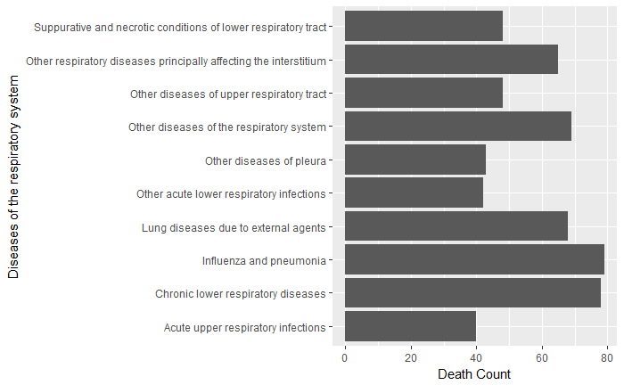

```r
data = subset(deathf, ICD.Chapter.Code %in% c("J00-J98"))
ggplot(data) +
  geom_bar(aes(x=ICD.Sub.Chapter)) +
  xlab("Diseases of the respiratory system") +
  ylab("Death Count") +
  coord_flip()
```

#### 3. Detailed Mortality, questions about the data

[6 points]

Cite your sources with links.

1. Who is included in the death counts?

site: (https://wonder.cdc.gov/controller/datarequest/D76)

Data is of:

U.S. civilians, Female and Male Noninstitutionalized population and the Age ranges from <1 - 85+

2. When was this query processed? (Hint: it’s in the file itself; don’t provide the file time stamp.)

if scrolling down to the bottom of the txt file, it’s “Query Date: Feb 5, 2018 5:08:43 PM” Also, I found the Notes unique column

```r
factor(unique(deathf$Notes))[24]
```

```
[1] Query Date: Feb 5, 2018 5:08:43 PM
40 Levels:  ... Year/Month: 2015
```

3. What does “ICD” stand for? Which version is used for this particular dataset? Name five other countries that use the ICD for official mortality data.

“ICD” is an acronym for “International Classification Of Diseases”. (inside the data) This version is Underlying Cause of Death 1999-2016, specifically 2015, for all states in U.S. (inside the data) Belgium, Denmark, Canada, China, France. (https://www.cdc.gov/globalhealth/countries/default.htm)

4. Which U.S. organizations collects mortality data? Where is the headquarters located?

NCHS Organization (https://www.cdc.gov/nchs/about/index.htm) Headquarters Hyattsville, MD (https://en.wikipedia.org/wiki/National_Center_for_Health_Statistics)

5. In brief, how is the data collected? What is the estimated accuracy rate, according to the dataset documentation?

Data is collected via surveys, personal interviews in households, by phone, from other agencies and private partners. (wikipedia and https://www.cdc.gov/nchs/data/factsheets/factsheet_health_statistics.htm) The NCHS mainly goes over their data gathering process. they do not mention the estimated accuracy rate. Accuracy is at a global level of satisfaction, but it is not explicitely mentioned. (https://www.cdc.gov/nchs/data/factsheets/factsheet_nhis.htm)

### Chapter 5

#### 1. Movie ratings

[12 points]

Explore *length* vs. *year* in the **ggplot2movies** dataset, after removing outliers. (Choose a reasonable cutoff).

Draw four scatterplots of *length* vs. *year* from the with the following variations:

1. Points with alpha blending

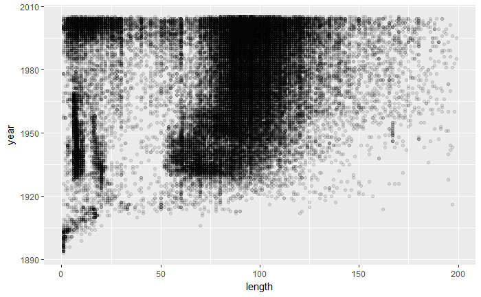

```r
# install.packages("ggplot2movies")
# library(ggplot2movies)
dataf <- subset(ggplot2movies::movies, length < 200)
ggplot(dataf, aes(x=length, y=year))+
  geom_point(alpha=.1)
```

2. Points with alpha blending + density estimate contour lines

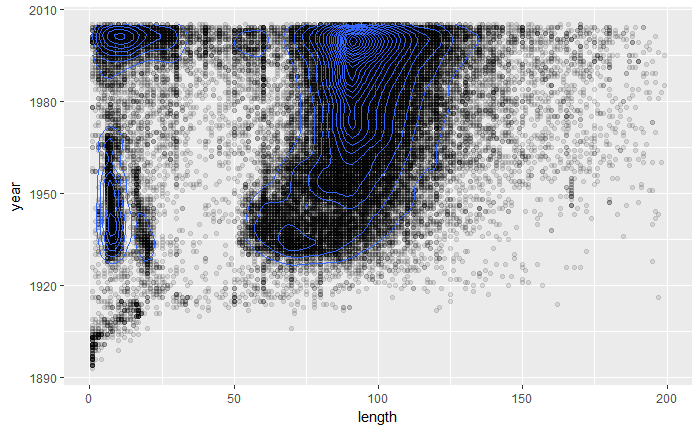

```r
ggplot(dataf, aes(x=length, y=year))+
  geom_point(alpha=.1)+
  geom_density2d(bins=22)
```

3. Hexagonal heatmap of bin counts

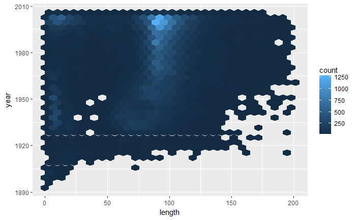

```r
ggplot(dataf, aes(x=length, y=year))+
  geom_hex(bin=10)
```

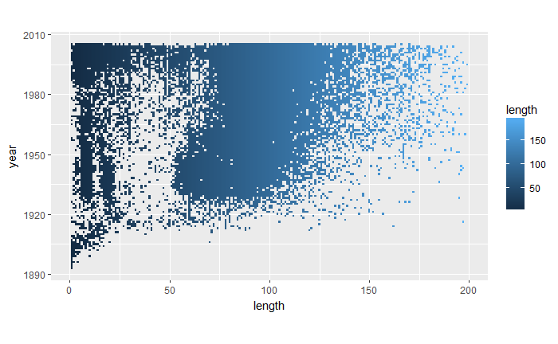

```r
ggplot(dataf, aes(length, year, fill=length)) +
  geom_tile() +
  coord_equal()
```

```r
NA
```

For all, adjust parameters to the levels that provide the best views of the data.

#### 2. Leaves (Chapter 5 exercises, #7, p. 96)

[6 points]

```r
DAAG::leafshape
```

|  | bladelen | petiole | bladewid | latitude | logwid | logpet | loglen | arch | location |
| --- | --- | --- | --- | --- | --- | --- | --- | --- | --- |
| 1 | 33.880000 | 1.40263200 | 13.650 | 5.0 | 2.6137395 | 0.3383504716 | 3.5228249 | 0 | Sabah |
| 2 | 33.320000 | 1.01626000 | 10.260 | 5.0 | 2.3282528 | 0.0161292219 | 3.5061578 | 0 | Sabah |
| 3 | 29.350000 | 2.39202500 | 12.210 | 5.0 | 2.5022553 | 0.8721402875 | 3.3792925 | 0 | Sabah |
| 4 | 26.870000 | 0.80878700 | 8.700 | 5.0 | 2.1633230 | -0.2122196846 | 3.2910104 | 0 | Sabah |
| 5 | 26.670000 | 0.80276700 | 8.410 | 5.0 | 2.1294215 | -0.2196907690 | 3.2835393 | 0 | Sabah |
| 6 | 24.230000 | 1.49014500 | 7.700 | 5.0 | 2.0412203 | 0.3988734307 | 3.1875915 | 0 | Sabah |
| 7 | 23.850000 | 1.09233000 | 5.690 | 5.0 | 1.7387102 | 0.0883130295 | 3.1717842 | 0 | Sabah |
| 8 | 23.300000 | 1.91060000 | 8.410 | 5.0 | 2.1294215 | 0.6474173289 | 3.1484534 | 0 | Sabah |
| 9 | 23.110000 | 1.88115400 | 7.950 | 5.0 | 2.0731719 | 0.6318854183 | 3.1402654 | 0 | Sabah |
| 10 | 23.080000 | 0.97628400 | 6.980 | 5.0 | 1.9430489 | -0.0240017513 | 3.1389664 | 0 | Sabah |

[output cut: 276 more lines]

```r
dataf <- data.frame(DAAG::leafshape)
head(dataf)
```

|  | bladelen | petiole | bladewid | latitude | logwid | logpet | loglen | arch | location |
| --- | --- | --- | --- | --- | --- | --- | --- | --- | --- |
| 1 | 33.88 | 1.402632 | 13.65 | 5 | 2.613740 | 0.33835047 | 3.522825 | 0 | Sabah |
| 2 | 33.32 | 1.016260 | 10.26 | 5 | 2.328253 | 0.01612922 | 3.506158 | 0 | Sabah |
| 3 | 29.35 | 2.392025 | 12.21 | 5 | 2.502255 | 0.87214029 | 3.379293 | 0 | Sabah |
| 4 | 26.87 | 0.808787 | 8.70 | 5 | 2.163323 | -0.21221968 | 3.291010 | 0 | Sabah |
| 5 | 26.67 | 0.802767 | 8.41 | 5 | 2.129421 | -0.21969077 | 3.283539 | 0 | Sabah |
| 6 | 24.23 | 1.490145 | 7.70 | 5 | 2.041220 | 0.39887343 | 3.187592 | 0 | Sabah |

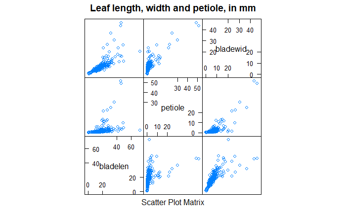

```r
# library(lattice)
splom(dataf[1:3],dataf, main = "Leaf length, width and petiole, in mm")
```

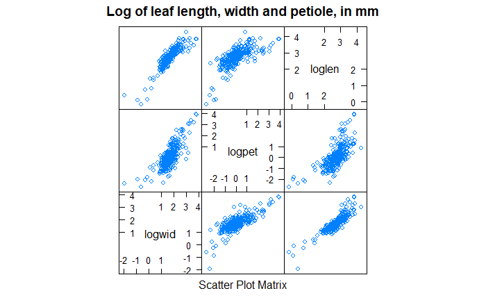

```r
splom(dataf[5:7], dataf, main = "Log of leaf length, width and petiole, in mm")
```

It’s more useful to use the log data because it is more centered in the graphs which allows us to view the patterns and shape more clearly

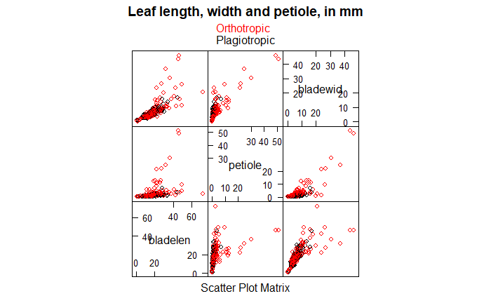

```r
arch <- as.factor(dataf[,8])
splom(dataf[1:3],dataf, main = "Leaf length, width and petiole, in mm", col=factor(arch), key=list(col=c("Red","Black"), text=list(c("Orthotropic", "Plagiotropic"))))
```

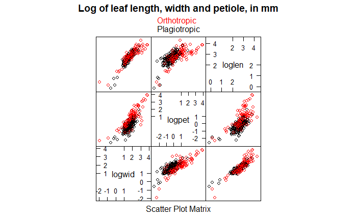

```r
splom(dataf[5:7], dataf, main = "Log of leaf length, width and petiole, in mm",col=factor(arch), key=list(col=c("Red","Black"), text=list(c("Orthotropic", "Plagiotropic"))))
```

1. We can now see that there are two arch types, Orthotropic and Plagiotropic
2. It also looks like Orthotropic leftypes are longer and wider
3. there are more outliers with the Orthotropic leaves, it appears